# Assessing patient-reported outcomes, pharmacist interventions and medication adherence in Dermatology and Asthma, Sinus, and Allergy Program (ASAP)

Ryan Moore

Leena Choi

Department of Biostatistics

Vanderbilt University Medical Center

2022-09-12

# 1 Study Details

## 1.1 Study title

**Assessing patient-reported outcomes, pharmacist interventions and medication adherence in Dermatology and Asthma, Sinus and Allergy Program (ASAP)**

## 1.2 Background

Patient reported outcomes (PROs), defined as a measurement of any aspect of a patient’s health status that comes directly from the patient, are an effective took for understanding patient insights into their disease management, quality of life and functioning and can help inform clinical decision making and improve quality of care. VSP’s current workflow captures specific PROs during monthly refill assessments and alerts the pharmacist of any negative findings. An integrated clinic pharmacist then performs a variety of interventions to facilitate medication adherence and identify medication safety or effectiveness or further coordination of care.

## 1.3 Objectives

- Quantify patient-reported response to therapy
- Quantify number and type of pharmacist interventions performed during monthly refill assessments.

## 1.4 Inclusion criteria

- Patients with at least two medication fills through VSP between January and March 2020.
- Prescribed specialty therapy by a VUMC ASAP or dermatology clinic provider.
- Patient associated with the ASAP (Asthma and allergy) or dermatology clinic.

# 2 Dermatology

## 2.1 Descriptive statistics

### 2.1.1 Demographics

There were 144 unique Dermatology patients that completed 455 MRQs.

| Demographics | Demographics N | Demographics *N=144* |
| --- | --- | --- |
| Age at start | 144 | 40 53 63 (51 ±16) |
| Gender | 144 |  |
| Female |  | 58% (83) |
| Male |  | 42% (61) |
| Race | 144 |  |
| White |  | 79.2% (114) |
| Black or African American |  | 15.3% ( 22) |
| Other Asian |  | 2.1% ( 3) |
| Unknown |  | 2.8% ( 4) |
| Asian Indian |  | 0.7% ( 1) |
| Ethnicity | 144 |  |
| Not Hispanic, Latino/a, or Spanish origin |  | 90.3% (130) |
| Unknown |  | 8.3% ( 12) |
| Decline to Answer |  | 0.7% ( 1) |
| Mexican, Mexican American, or Chicano/a |  | 0.7% ( 1) |
| Insurance type | 144 |  |
| Commercial |  | 66.0% (95) |
| Medicare |  | 30.6% (44) |
| Medicaid |  | 2.8% ( 4) |
| Other |  | 0.7% ( 1) |

*a* *b* *c* represent the lower quartile *a*, the median *b*, and the upper quartile *c* for continuous variables. *x ± s* represents X ± 1 SD. *N* is the number of non-missing values. Numbers after proportions are frequencies.

### 2.1.2 Medications

| Medications and indications | Medications and indications N | Medications and indications *N=144* |
| --- | --- | --- |
| Administration route | 144 |  |
| Oral |  | 10% ( 15) |
| Subcutaneous |  | 90% (129) |
| Speciality medication | 144 |  |
| Cimzia (certolizumab) |  | 1.4% ( 2) |
| Cosentyx (secukinumab) |  | 13.9% (20) |
| Dupixent (dupilumab) |  | 21.5% (31) |
| Taltz (ixekizumab) |  | 2.8% ( 4) |
| Humira (adalimumab) |  | 24.3% (35) |
| Otezla (apremilast) |  | 16.7% (24) |
| Enbrel (etanercept) |  | 6.9% (10) |
| Siliq (brodalumab) |  | 0.7% ( 1) |
| Simponi (golimumab) |  | 0.7% ( 1) |
| Stelara (ustekinumab) |  | 2.1% ( 3) |
| Targretin (bexarotene) |  | 4.9% ( 7) |
| Tremfya (guselkumab) |  | 3.5% ( 5) |
| Xeljanz (tofacitinib) |  | 0.7% ( 1) |
| Indication | 144 |  |
| Plaque psoriasis |  | 63.9% (92) |
| Atopic dermatitis |  | 21.5% (31) |
| Hidradenitis suppurativa |  | 8.3% (12) |
| Other |  | 2.8% ( 4) |
| Mycosis fungoides |  | 3.5% ( 5) |
| Medication switch | 144 |  |
| Yes |  | 2.8% ( 4) |
| No |  | 2.1% ( 3) |
| NA |  | 95.1% (137) |
| Medication change | 144 |  |
| Otezla |  | 0.7% ( 1) |
| taltz |  | 0.7% ( 1) |
| tremfya |  | 0.7% ( 1) |
| Xeljanz |  | 0.7% ( 1) |
| NA |  | 97.2% (140) |

*N* is the number of non-missing values. Numbers after proportions are frequencies.

### 2.1.3 Previous biologics

#### 2.1.3.1 Count of medications

Previous Dermatology biologics

| Medication | Count |
| --- | --- |
| No previous treatments | 78 |
| Humira (adalimumab) | 35 |
| Stelara (ustekinumab) | 24 |
| Enbrel (etanercept) | 23 |
| Cosentyx (secukinumab) | 10 |
| Otezla (apremilast) | 9 |
| Unknown/not documented | 9 |
| Remicade (infliximab) | 5 |
| Tremfya (guselkumab) | 4 |
| Taltz (ixekizumab) | 3 |
| Cimzia (certolizumab) | 2 |
| Dupixent (dupilumab) | 2 |
| Skyrizi (risankizumab) | 1 |

#### 2.1.3.2 Count of medications per patient

Count of previous biologics per patient

| NumberPreviousMeds | Count |
| --- | --- |
| 0 | 87 |
| 1 | 26 |
| 2 | 13 |
| 3 | 10 |
| 4 | 6 |
| 5 | 1 |
| 7 | 1 |

## 2.2 MRQs

### 2.2.1 Number of MRQs per patient

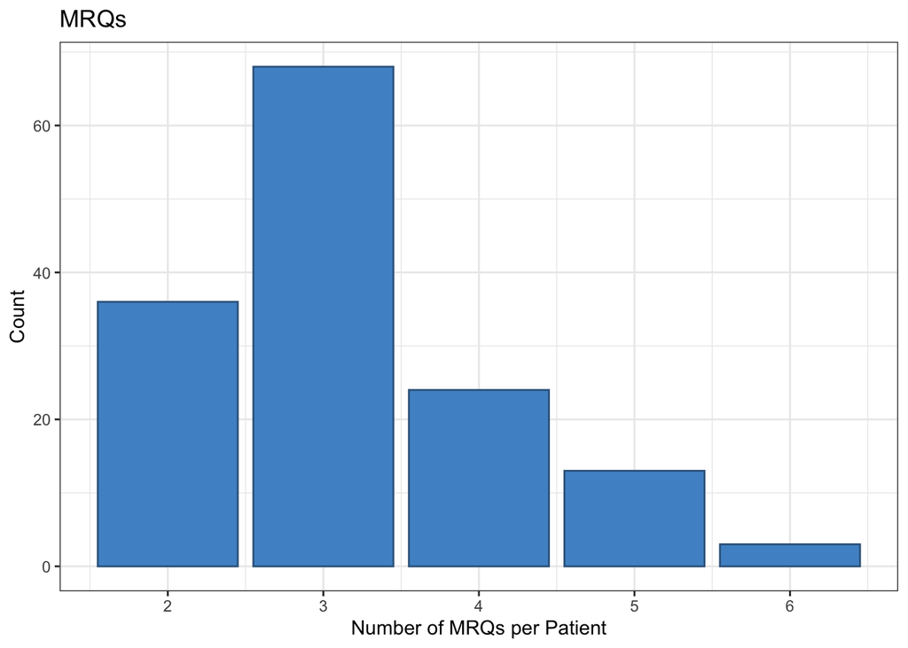

### 2.2.2 Missed doses

#### 2.2.2.1 Missed doses per patient

| Missed doses per patient. | Missed doses per patient. *N=144* |
| --- | --- |
| Number of Missed Doses |  |
| 0 | 0.96 (138) |
| 1 | 0.04 ( 6) |

Numbers after proportions are frequencies.

#### 2.2.2.2 Missed doses in the last month per MRQ

| Missed doses in the last month per MRQ. | Missed doses in the last month per MRQ. *N=455* |
| --- | --- |
| Number of missed doses |  |
| 1-2 doses | 0.01 ( 6) |
| NA | 0.99 (449) |

Numbers after proportions are frequencies.

#### 2.2.2.3 Reasons for missed doses

Reasons for Missed Doses by MRQ

| Reasons | Frequency |
| --- | --- |
| Purposefully Held Due to Illness or Procedure | 4 |
| Forgetfulness | 2 |

### 2.2.3 Patient perceived efficacy

#### 2.2.3.1 Table

| Patient reported medication effectiveness. | Patient reported medication effectiveness. *N=455* |
| --- | --- |
| Effectiveness |  |
| Fair | 0.01 ( 6) |
| Good | 0.91 (412) |
| Excellent | 0.08 ( 36) |
| NA | 0.00 ( 1) |

Numbers after proportions are frequencies.

#### 2.2.3.2 Visualization

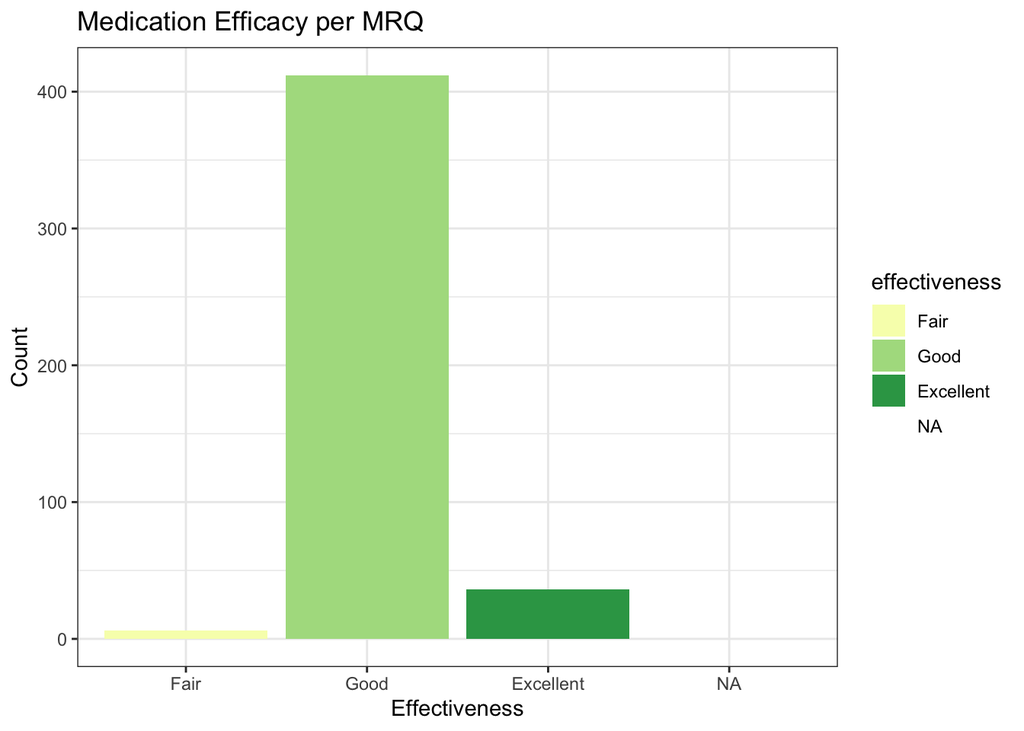

### 2.2.4 Adverse effects

| Descriptive Statistics *(N=455)*. | Descriptive Statistics *(N=455)*. *N=455* |
| --- | --- |
| Adverse effects |  |
| No | 0.99 (451) |
| Yes | 0.01 ( 4) |

Numbers after proportions are frequencies.

## 2.3 Pharmacist Intervention

### 2.3.1 Interventions per Patient

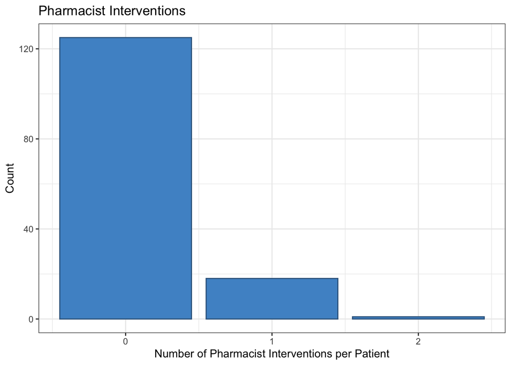

### 2.3.2 Types of Interventions

Total count of types of pharmacist interventions by intervention

| Interventions | Frequency |
| --- | --- |
| Adherence/Missed Dose | 7 |
| Common Side Effect/Toxicity | 4 |
| ED/Hospitalization/Urgent Care Visit | 3 |
| Medication List Change | 3 |
| Other | 3 |
| Condition-Related Concern or Exacerbation | 2 |

## 2.4 Discontinuations

Therapy Discontinuations

| Discontinuation Reason | Frequency |
| --- | --- |
| Common side effects | 1 |
| Major side effects/complication | 1 |
| No longer being seen or followed by a Vanderbilt Provider | 2 |
| No response / suboptimal response to therapy | 4 |

# 3 ASAP

## 3.1 Descriptive statistics

There were 46 unique ASAP patients that completed 142 MRQS.

### 3.1.1 Demographics

| Demographics, medications, and disease states | Demographics, medications, and disease states N | Demographics, medications, and disease states *N=46* |
| --- | --- | --- |
| Age at start | 46 | 41 50 62 (50 ±19) |
| Gender | 46 |  |
| Female |  | 59% (27) |
| Male |  | 41% (19) |
| Race | 46 |  |
| White |  | 67.4% (31) |
| Black or African American |  | 28.3% (13) |
| Other |  | 2.2% ( 1) |
| Decline to Answer |  | 2.2% ( 1) |
| Ethnicity | 46 |  |
| Not Hispanic, Latino/a, or Spanish origin |  | 89.1% (41) |
| Unknown |  | 4.3% ( 2) |
| Other Hispanic, Latino/a, or Spanish origin |  | 6.5% ( 3) |
| Insurance type | 46 |  |
| Commercial |  | 52.2% (24) |
| Medicare |  | 39.1% (18) |
| Medicaid |  | 8.7% ( 4) |
| Patient status | 46 |  |
| Living |  | 100% (46) |
| Specialty medication | 46 |  |
| Dupixent (dupilumab) |  | 82.6% (38) |
| Fasenra (benralizumab) |  | 2.2% ( 1) |
| Gamunex-C (immune globulin injection) |  | 2.2% ( 1) |
| Hizentra (immune globulin injection) |  | 2.2% ( 1) |
| Nucala (mepolizumab) |  | 6.5% ( 3) |
| Xolair (omalizumab) |  | 4.3% ( 2) |
| Indication | 46 |  |
| Moderate to severe asthma |  | 93.5% (43) |
| Primary humoral immunodeficiency |  | 4.3% ( 2) |
| Rhinosinusitis (chronic) with nasal polyposis |  | 2.2% ( 1) |
| Smoking | 46 |  |
| Never smoker |  | 65.2% (30) |
| Former smoker |  | 30.4% (14) |
| Current smoker |  | 4.3% ( 2) |

*a* *b* *c* represent the lower quartile *a*, the median *b*, and the upper quartile *c* for continuous variables. *x ± s* represents X ± 1 SD. *N* is the number of non-missing values. Numbers after proportions are frequencies.

### 3.1.2 Disease state and indication by specialty medication

| Disease state by indication | Disease state by indication N | Disease state by indication Moderate to severe asthma *N=43* | Disease state by indication Primary humoral immunodeficiency *N=2* | Disease state by indication Rhinosinusitis (chronic) with nasal polyposis *N=1* |
| --- | --- | --- | --- | --- |
| Specialty medication | 46 |  |  |  |
| Dupixent (dupilumab) |  | 86.0% (37) | 0.0% ( 0) | 100.0% ( 1) |
| Fasenra (benralizumab) |  | 2.3% ( 1) | 0.0% ( 0) | 0.0% ( 0) |
| Gamunex-C (immune globulin injection) |  | 0.0% ( 0) | 50.0% ( 1) | 0.0% ( 0) |
| Hizentra (immune globulin injection) |  | 0.0% ( 0) | 50.0% ( 1) | 0.0% ( 0) |
| Nucala (mepolizumab) |  | 7.0% ( 3) | 0.0% ( 0) | 0.0% ( 0) |
| Xolair (omalizumab) |  | 4.7% ( 2) | 0.0% ( 0) | 0.0% ( 0) |

*N* is the number of non-missing values. Numbers after proportions are frequencies.

### 3.1.3 Previous ASAP biologics

#### 3.1.3.1 Count of medications

Previous ASAP biologics

| Medication | Count |
| --- | --- |
| Xolair (omalizumab) | 16 |
| Nucala (mepolizumab) | 11 |
| Fasenra (benralizumab) | 4 |
| Dupixent (dupilumab) | 2 |
| Cinqair (reslizumab) | 2 |

#### 3.1.3.2 Count of medications per patient

Count of previous biologics per patient

| NumberPreviousMeds | Count |
| --- | --- |
| 1 | 20 |
| 0 | 19 |
| 2 | 6 |
| 3 | 1 |

## 3.2 MRQs

### 3.2.1 Number of MRQs per patient

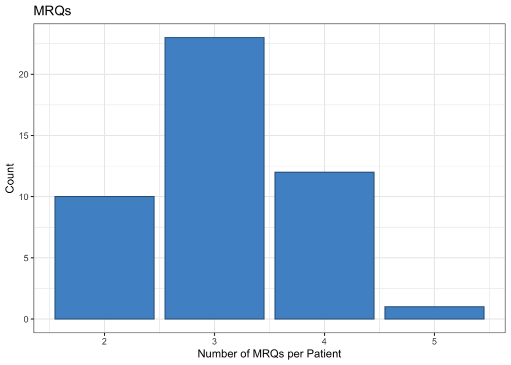

### 3.2.2 Missed doses

| Descriptive Statistics *(N=46)*. | Descriptive Statistics *(N=46)*. *N=46* |
| --- | --- |
| Number of Missed Doses |  |
| 0 | 1 (46) |
| 1 | 0 ( 0) |

Numbers after proportions are frequencies.

### 3.2.3 Patient perceived efficacy

#### 3.2.3.1 Count per MRQ

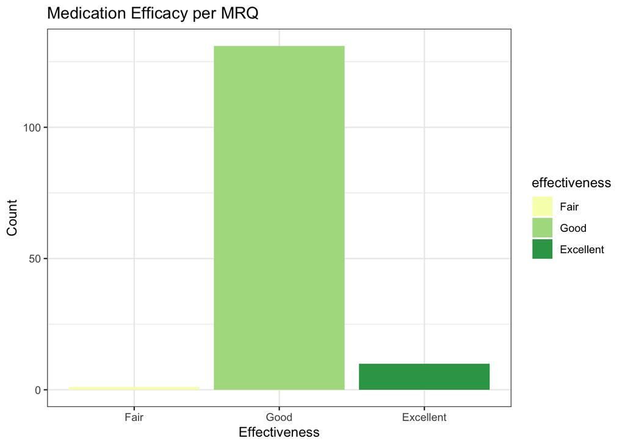

#### 3.2.3.2 Count per patient

Patients had multiple MRQs. The proportion of patients that gave each effectiveness measurement at least once are provided to count effectiveness at a patient level.

| MRQ Effectiveness - patient level. | MRQ Effectiveness - patient level. *N=46* |
| --- | --- |
| Fair |  |
| No | 0.98 (45) |
| Yes | 0.02 ( 1) |
| Good |  |
| No | 0 ( 0) |
| Yes | 1 (46) |
| Excellent |  |
| No | 0.85 (39) |
| Yes | 0.15 ( 7) |

Numbers after proportions are frequencies.

### 3.2.4 Adverse effects per MRQ

| Descriptive Statistics *(N=142)*. | Descriptive Statistics *(N=142)*. *N=142* |
| --- | --- |
| Adverse effects |  |
| No | 0.99 (141) |
| Yes | 0.01 ( 1) |

Numbers after proportions are frequencies.

## 3.3 Pharmacist Interventions

### 3.3.1 Number of Interventions per Patient

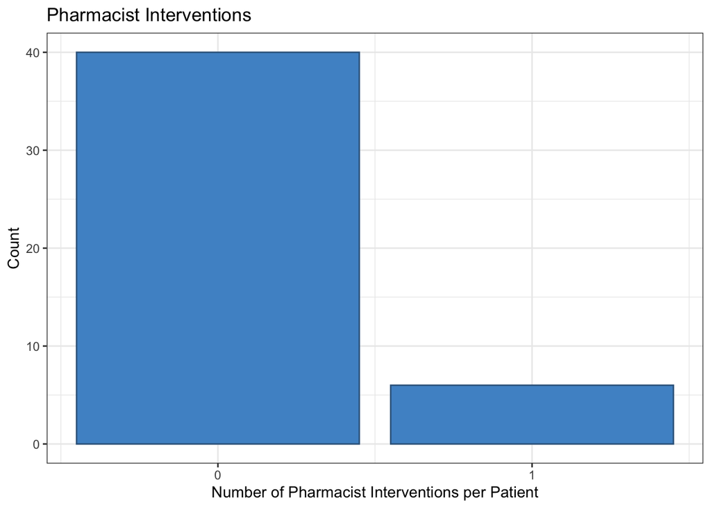

### 3.3.2 Types of Interventions

Total count of types of pharmacist interventions by intervention

| Interventions | Frequency |
| --- | --- |
| Other | 3 |
| Condition-Related Concern or Exacerbation | 2 |
| Coordination of Care | 1 |
| Medication List Change | 1 |

### 3.3.3 Intervention count details

Unique intervention count from raw data

| . | Freq |
| --- | --- |
| Condition-Related Concern or Exacerbation | 2 |
| Medication List Change | 1 |
| Other General Drug Information Needed | 2 |
| Other General Drug Information Needed;Coordination of Care | 1 |

## 3.4 Discontinuations

1 patients discontinued medication for the following reasons:

Therapy Discontinuations

| Discontinuation Reason | Frequency |
| --- | --- |
| No response / suboptimal response to therapy | 1 |